# Wisconsin Breast Cancer Analysis

Gokul Shanth Raveendran

2/18/2020

Let’s load the libraries we will be using

```r
rm(list=ls())
library(rio)
library(dplyr)
library(caret)
```

Let’s read the dataset into the dataframe.

```r
breastCancer=import("WiscBreastCancer.csv")
summary(breastCancer)
```

```
##        Id            Cl.thickness      Cell.size        Cell.shape
##  Min.   :   61634   Min.   : 1.000   Min.   : 1.000   Min.   : 1.000
##  1st Qu.:  870688   1st Qu.: 2.000   1st Qu.: 1.000   1st Qu.: 1.000
##  Median : 1171710   Median : 4.000   Median : 1.000   Median : 1.000
##  Mean   : 1071704   Mean   : 4.418   Mean   : 3.134   Mean   : 3.207
##  3rd Qu.: 1238298   3rd Qu.: 6.000   3rd Qu.: 5.000   3rd Qu.: 5.000
##  Max.   :13454352   Max.   :10.000   Max.   :10.000   Max.   :10.000
##
##  Marg.adhesion     Epith.c.size     Bare.nuclei      Bl.cromatin
##  Min.   : 1.000   Min.   : 1.000   Min.   : 1.000   Min.   : 1.000
##  1st Qu.: 1.000   1st Qu.: 2.000   1st Qu.: 1.000   1st Qu.: 2.000
##  Median : 1.000   Median : 2.000   Median : 1.000   Median : 3.000
##  Mean   : 2.807   Mean   : 3.216   Mean   : 3.545   Mean   : 3.438
##  3rd Qu.: 4.000   3rd Qu.: 4.000   3rd Qu.: 6.000   3rd Qu.: 5.000
##  Max.   :10.000   Max.   :10.000   Max.   :10.000   Max.   :10.000
##                                    NA's   :16
##  Normal.nucleoli     Mitoses          Class
##  Min.   : 1.000   Min.   : 1.000   Length:699
##  1st Qu.: 1.000   1st Qu.: 1.000   Class :character
##  Median : 1.000   Median : 1.000   Mode  :character
##  Mean   : 2.867   Mean   : 1.589
##  3rd Qu.: 4.000   3rd Qu.: 1.000
##  Max.   :10.000   Max.   :10.000
##
```

On going through the dataset, out of the 699 rows, I could see some rows had NA values in some of the rows. So let’s take a look at all the complete cases.

```r
breastCancer = breastCancer[complete.cases(breastCancer), ]
breastCancer <- subset(breastCancer, select = -c(Id))
```

The number of observations reduced from 699 to 683, so 16 rows were removed.

```r
breastCancer$Class = as.factor(breastCancer$Class)
breastCancer %>%
  group_by(Class) %>%
  tally()
```

```
## # A tibble: 2 x 2
##   Class         n
##   <fct>     <int>
## 1 benign      444
## 2 malignant   239
```

We converted the target variable, that is class into a factor. We can see that there are almost twice the amount of benign classifications than malignant, while the target variable is skewed but only slightly. I don’t think we’ll need to sample the dataset to take an almost equal number of benign and malignant rows.

```r
set.seed(101) # Set Seed so that same sample can be reproduced
sample = sample.int(n = nrow(breastCancer), size = floor(.80*nrow(breastCancer)), replace = F)
train = breastCancer[sample, ]
test  = breastCancer[-sample, ]
train %>%
  group_by(Class) %>%
  tally()
```

```
## # A tibble: 2 x 2
##   Class         n
##   <fct>     <int>
## 1 benign      354
## 2 malignant   192
```

```r
test %>%
  group_by(Class) %>%
  tally()
```

```
## # A tibble: 2 x 2
##   Class         n
##   <fct>     <int>
## 1 benign       90
## 2 malignant    47
```

We split the data into 80% train and 20% test.

```r
model1 <-glm(Class~.,family=binomial,data=train)
summary(model1)
```

```
##
## Call:
## glm(formula = Class ~ ., family = binomial, data = train)
##
## Deviance Residuals:
##      Min        1Q    Median        3Q       Max
## -3.02181  -0.08844  -0.04511   0.01027   2.52992
##
## Coefficients:
##                 Estimate Std. Error z value Pr(>|z|)
## (Intercept)     -11.2480     1.6273  -6.912 4.77e-12 ***
## Cl.thickness      0.6261     0.1738   3.603 0.000314 ***
## Cell.size         0.1430     0.2830   0.505 0.613410
## Cell.shape        0.1722     0.3120   0.552 0.580918
## Marg.adhesion     0.4366     0.1474   2.961 0.003065 **
## Epith.c.size      0.0297     0.1767   0.168 0.866504
## Bare.nuclei       0.3850     0.1084   3.552 0.000382 ***
## Bl.cromatin       0.5304     0.1985   2.673 0.007527 **
## Normal.nucleoli   0.2772     0.1325   2.092 0.036453 *
## Mitoses           0.6672     0.3800   1.756 0.079109 .
## ---
## Signif. codes:  0 '***' 0.001 '**' 0.01 '*' 0.05 '.' 0.1 ' ' 1
##
## (Dispersion parameter for binomial family taken to be 1)
##
##     Null deviance: 708.119  on 545  degrees of freedom
## Residual deviance:  72.231  on 536  degrees of freedom
## AIC: 92.231
##
## Number of Fisher Scoring iterations: 9
```

So let us make another mode keeping these features in them. Keeping all of them might overfit the model.

```r
model <- glm(Class~Cl.thickness
             +Marg.adhesion+Bare.nuclei
             +Bl.cromatin+Normal.nucleoli
             +Mitoses,
             family=binomial,data=train)
summary(model)
```

```
##
## Call:
## glm(formula = Class ~ Cl.thickness + Marg.adhesion + Bare.nuclei +
##     Bl.cromatin + Normal.nucleoli + Mitoses, family = binomial,
##     data = train)
##
## Deviance Residuals:
##     Min       1Q   Median       3Q      Max
## -3.3135  -0.0900  -0.0400   0.0073   2.3632
##
## Coefficients:
##                  Estimate Std. Error z value Pr(>|z|)
## (Intercept)     -11.76930    1.61249  -7.299 2.90e-13 ***
## Cl.thickness      0.74823    0.15937   4.695 2.67e-06 ***
## Marg.adhesion     0.50636    0.14134   3.583 0.000340 ***
## Bare.nuclei       0.44150    0.09949   4.437 9.11e-06 ***
## Bl.cromatin       0.62359    0.17344   3.595 0.000324 ***
## Normal.nucleoli   0.36354    0.12204   2.979 0.002894 **
## Mitoses           0.71008    0.37433   1.897 0.057837 .
## ---
## Signif. codes:  0 '***' 0.001 '**' 0.01 '*' 0.05 '.' 0.1 ' ' 1
##
## (Dispersion parameter for binomial family taken to be 1)
##
##     Null deviance: 708.119  on 545  degrees of freedom
## Residual deviance:  74.888  on 539  degrees of freedom
## AIC: 88.888
##
## Number of Fisher Scoring iterations: 8
```

In logistic regression the equation can be written as log[p/(1-p)] = b0 + b1*x1 + b2*x2 + … + bn*xn The lhs is called log/odds which reflect the likelihood of the occurence of an event. Odds is the probability of an event divided by the probability that the event will not take place.

All the coefficients are positive, which say that an increase in any of those will increase the probability of tumor beign malignant. For example, the cell thickness is 0.74823, then 1 unit of increase in cell thickness will increase the odds of tumour being malignant by exp(0.74823) i.e 2.1 times.

```r
prediction<- predict(model, test)
probs <- exp(prediction)/(1+exp(prediction))
output <- cbind(test, probs)
output <- output %>%
  mutate(probs = ifelse(probs >0.5,1,0))
output <- output %>%
  mutate(ClassNo = ifelse(Class == "malignant",1,0))
cm <- confusionMatrix(as.factor(output$probs),as.factor(output$ClassNo))
cm
```

```
## Confusion Matrix and Statistics
##
##           Reference
## Prediction  0  1
##          0 88  3
##          1  2 44
##
##                Accuracy : 0.9635
##                  95% CI : (0.9169, 0.988)
##     No Information Rate : 0.6569
##     P-Value [Acc > NIR] : <2e-16
##
##                   Kappa : 0.9186
##
##  Mcnemar's Test P-Value : 1
##
##             Sensitivity : 0.9778
##             Specificity : 0.9362
##          Pos Pred Value : 0.9670
##          Neg Pred Value : 0.9565
##              Prevalence : 0.6569
##          Detection Rate : 0.6423
##    Detection Prevalence : 0.6642
##       Balanced Accuracy : 0.9570
##
##        'Positive' Class : 0
##
```

```r
cm$byClass["F1"]
```

```
##        F1
## 0.9723757
```

```r
cm$byClass["Precision"]
```

```
## Precision
##  0.967033
```

```r
cm$byClass["Recall"]
```

```
##    Recall
## 0.9777778
```

Let us plot the S curve for the regression

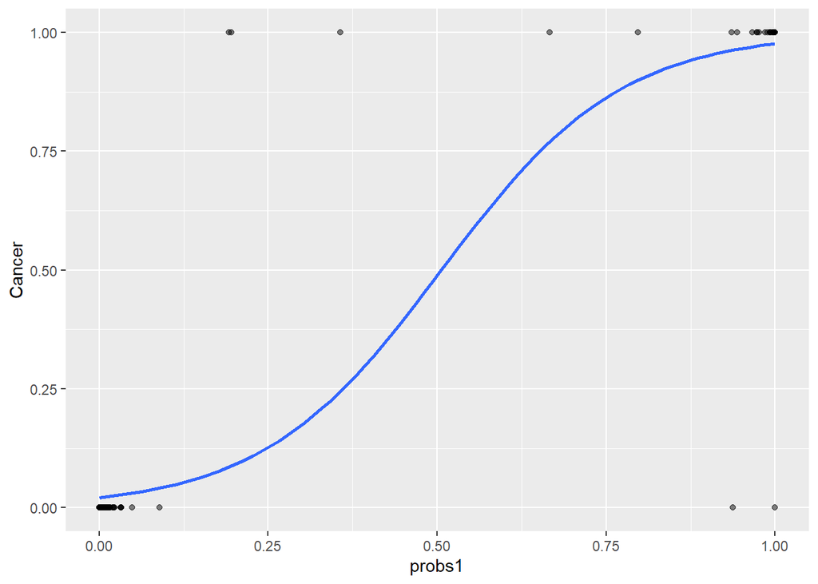

```r
probs1 = probs
output <- cbind(output, probs1)
ggplot(output, aes(x=probs1, y=as.numeric(output$ClassNo))) +
  geom_point(alpha=.5) +
  stat_smooth(method="glm", se=FALSE, fullrange=TRUE,
              method.args = list(family=binomial)) +
  ylab("Cancer")
```

```r
anova(model, test="Chisq")
```

```
## Analysis of Deviance Table
##
## Model: binomial, link: logit
##
## Response: Class
##
## Terms added sequentially (first to last)
##
##
##                 Df Deviance Resid. Df Resid. Dev  Pr(>Chi)
## NULL                              545     708.12
## Cl.thickness     1   370.13       544     337.99 < 2.2e-16 ***
## Marg.adhesion    1   144.58       543     193.40 < 2.2e-16 ***
## Bare.nuclei      1    77.27       542     116.13 < 2.2e-16 ***
## Bl.cromatin      1    26.67       541      89.46 2.415e-07 ***
## Normal.nucleoli  1    10.47       540      78.99  0.001211 **
## Mitoses          1     4.10       539      74.89  0.042938 *
## ---
## Signif. codes:  0 '***' 0.001 '**' 0.01 '*' 0.05 '.' 0.1 ' ' 1
```

```r
library(ROCR)
library(Metrics)
```

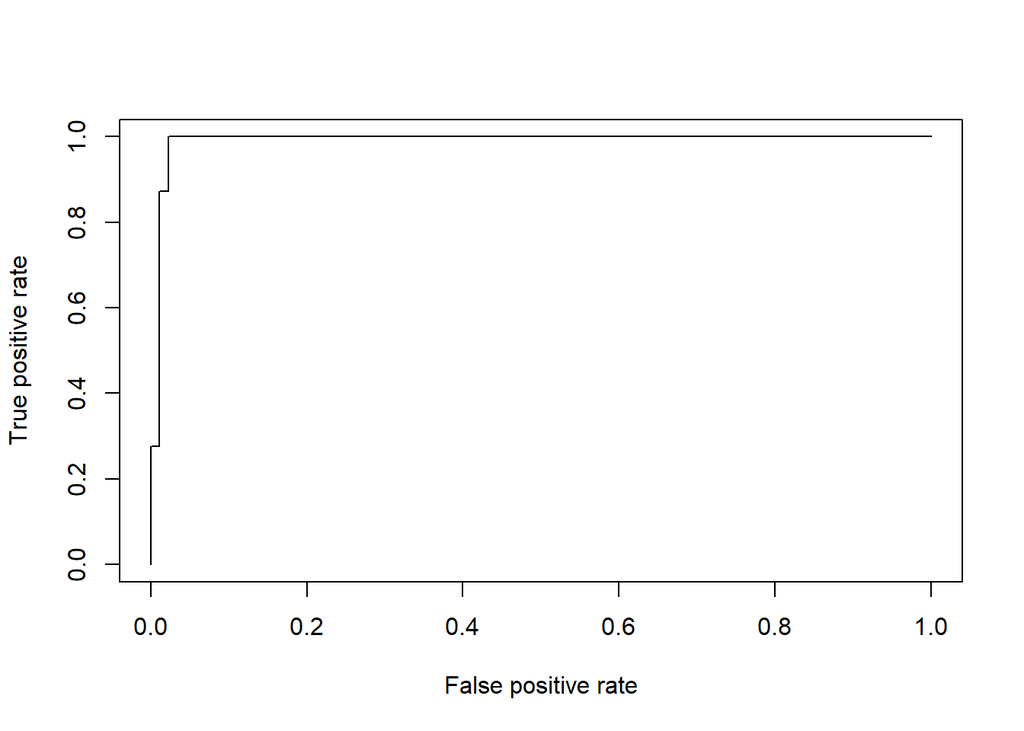

```r
pr <- prediction(prediction,output$ClassNo)
perf <- performance(pr,measure = "tpr",x.measure = "fpr")
plot(perf)
```

```r
auc(output$ClassNo,prediction)
```

```
## [1] 0.9905437
```

Questions 1. What method will you use for your analysis and why? Since this is a classification problem, I’m choosing a logistic regression model because my target variable is binary/dichotomus. I simply need to predict if the tumor is benign or malignant.

2. What response (Y) and predictor (X) variables will you use and why? The Y response is Class - Benign or Malignant The X variables chosen are Cl.thickness, Marg.adhesion, Bare.nuclei, Bl.cromatin, Normal.nucleoli, Mitoses. These appear to be most statistically significant when running on a base model.

4.How will you interpret the beta coefficients in this model? All the coefficients are positive, which say that an increase in any of those will increase the probability of tumor beign malignant. For example, the cell thickness is 0.74823, then 1 unit of increase in cell thickness will increase the odds of tumour being malignant by exp(0.74823) i.e 2.1 times.

5.How will you estimate model fit? Using a Chisquare test.

6.Explain which measure of accuracy is most useful in this case and why. Recall or F1, but predicting someone’s tumor as malignant has a highest cost and thus Recall would be a good measure of accuracy.